# NickContributions

Nick Chandler

2025-12-01

## Introduction

In this report, we examine the application of two statistical learning methods to baseball data from the years 2020-2024. Specifically we are interested in predicting the next season’s batting average of arbitrary players given the standard and advanced metrics of the previous season from this source. The report begins with a quick exploratory data analysis (EDA), it then moves into a mathematical description of the statistical learning methods applied, then the application of each method, and finally a performance evaluation and description. This report illustrates how classical, interpretable methods can be applied, and then how more modern (and less interpretable) methods can be applied for better performance, and with the help of XAI, also be interpretable.

## EDA

Here we do a short exploratory analysis of the data to understand some of the basic characteristics.

The dataset has 1455 rows, 41 columns, and contains 559 unique players.

Transposed view of first 6 rows

| Season | Season of the game | 2020 | 2021 | 2022 | 2020 | 2021 | 2022 |
| --- | --- | --- | --- | --- | --- | --- | --- |
| Name | Player name | AJ Pollock | AJ Pollock | AJ Pollock | Aaron Hicks | Aaron Hicks | Aaron Hicks |
| Team | Team abbreviation | LAD | LAD | CHW | NYY | NYY | NYY |
| G | Games played | 55 | 117 | 138 | 54 | 32 | 130 |
| AB | At bats | 196 | 384 | 489 | 169 | 108 | 384 |
| H | Hits | 54 | 114 | 120 | 38 | 21 | 83 |
| X1B | Singles | 29 | 65 | 79 | 20 | 14 | 64 |
| X2B | Doubles | 9 | 27 | 26 | 10 | 3 | 9 |
| X3B | Triples | 0 | 1 | 1 | 2 | 0 | 2 |
| HR | Home runs | 16 | 21 | 14 | 6 | 4 | 8 |
| R | Runs scored | 30 | 53 | 61 | 28 | 13 | 54 |
| RBI | RBIs | 34 | 69 | 56 | 21 | 14 | 40 |
| BB | Walks | 12 | 30 | 32 | 41 | 14 | 62 |
| IBB | Intentional walks | 1 | 4 | 0 | 1 | 0 | 3 |
| SO | Strikeouts | 45 | 80 | 98 | 38 | 30 | 109 |
| HBP | Hit by pitch | 0 | 6 | 2 | 1 | 2 | 4 |
| SF | Sacrifice flies | 2 | 2 | 4 | 0 | 2 | 2 |
| SH | Sacrifice hits | 0 | 0 | 0 | 0 | 0 | 1 |
| GDP | Grounded into double plays | 6 | 4 | 13 | 4 | 3 | 10 |
| SB | Stolen bases | 2 | 9 | 3 | 4 | 0 | 10 |
| CS | Caught stealing | 2 | 1 | 1 | 1 | 0 | 3 |
| PA | Plate appearances | 210 | 422 | 527 | 211 | 126 | 453 |
| BB.Percent | Walk percentage | 0.057 | 0.071 | 0.061 | 0.194 | 0.111 | 0.137 |
| K.Percent | Strikeout percentage | 0.214 | 0.19 | 0.186 | 0.18 | 0.238 | 0.241 |
| BB.K | Walk/Strikeout ratio | 0.27 | 0.38 | 0.33 | 1.08 | 0.47 | 0.57 |
| AVG | Batting average | 0.276 | 0.297 | 0.245 | 0.225 | 0.194 | 0.216 |
| OBP | On-base percentage | 0.314 | 0.355 | 0.292 | 0.379 | 0.294 | 0.33 |
| SLG | Slugging percentage | 0.566 | 0.536 | 0.389 | 0.414 | 0.333 | 0.313 |
| OPS | OPS | 0.881 | 0.892 | 0.681 | 0.793 | 0.627 | 0.642 |
| ISO | Isolated power | 0.291 | 0.24 | 0.143 | 0.189 | 0.139 | 0.096 |
| Spd | Speed score | 2.6 | 4.4 | 3.5 | 5.7 | 1.3 | 5 |
| BABIP | BABIP | 0.277 | 0.326 | 0.278 | 0.256 | 0.224 | 0.279 |
| UBR | Ultimate base running | -0.7 | -1 | -0.9 | 1.9 | -0.1 | 2 |
| wGDP | Weighted GDP | -0.7 | 0.6 | -0.3 | 0.5 | 0 | 0.2 |
| XBR | Expected runs (XBR) | -0.4 | -0.1 | -2.1 | 0.8 | -0.2 | 0.3 |
| wSB | Weighted SB | -0.6 | 1 | -0.3 | 0.2 | -0.1 | 0.3 |
| wRC | Weighted runs created | 34 | 72 | 55 | 32 | 12 | 45 |
| wRAA | Weighted RAA | 7.8 | 21.1 | -5.2 | 5.6 | -3.7 | -6.3 |
| wOBA | Weighted OBA | 0.364 | 0.375 | 0.297 | 0.351 | 0.279 | 0.292 |
| wRC. | Weighted RC% | 130 | 137 | 92 | 124 | 77 | 89 |
| next_AVG | Next season AVG | 0.297 | 0.245 | 0.173 | 0.194 | 0.216 | 0.275 |

Total number of players in each season

[output not shown]

Correlation plots using Pearson’s correlation coefficient.

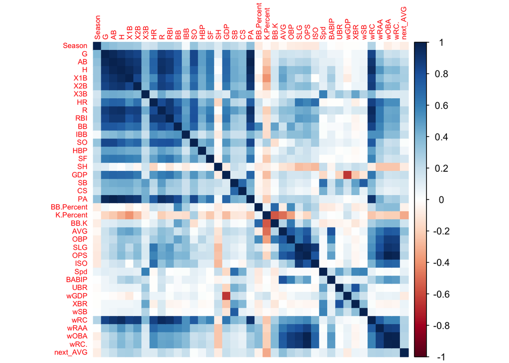

## Mathematical Description of Regularized Regression

This section examines the mathematical background for the regularized regression model types of: Ridge, Lasso, and Elastic-Net regression. All assume a model of the form (here, without interaction terms):
$$y = \beta_0 + \sum_{i=1}^{p} \beta_i x_i +
\varepsilon.$$
Where the $\beta_i$s are found by solving (though specific instances introduce additional terms):
$$\min_\vec{\beta} \left\| X\vec{\beta} - \vec{y}
\right\|^2_2\text{, with } X \in \mathbb{R}^{n \times p} \text{ the
design matrix}$$
The general solution is given (analytically) by:
$$\hat{\vec{\beta}} = \left(X^T X
\right)^{-1} X^T\vec{y}$$
We now explain the various cases of regularization.

### Ridge Regression

The Ridge regression penalizes the size of the parameters with an L2 norm. Specifically the optimization problem is given by,
$$\min_{\vec{\beta}} \left\| X\vec{\beta} - \vec{y}
\right\|_2^2 + \lambda \| \vec{\beta} \|_2^2$$

The analytical solution is given by:
$$\vec{\beta} = \left( X^TX + \lambda I \right)^{-1}X^T\vec{y}$$
Note that in the previous two equations, $\lambda$ is a hyperparameter that can be tuned with cross validation. We now proceed to Lasso Regression.

### Lasso Regression

The Lasso regression penalizes the size of the parameters with an L1 norm. The optimization problem is:
$$\min_{\vec{\beta}} \left\| X\vec{\beta} - \vec{y}
\right\|_2^2 + \lambda \| \vec{\beta} \|_1$$
Since the L1 norm is not differentiable at $0$, there is no closed-form, analytical solution to the above problem. One can use solvers for convex problems capable of dealing with non-smooth objectives. The optimality condition is given by:

$$0 \in 2 X^\top (X \hat{\beta} - y) + \lambda\, \partial
\|\hat{\beta}\|_1,
\quad
(\partial \|\hat{\beta}\|_1)_i =
\begin{cases}
\{1\}, & \hat{\beta}_i > 0,\\[1mm]
\{-1\}, & \hat{\beta}_i < 0,\\[1mm]
[-1,1], & \hat{\beta}_i = 0
\end{cases}$$

Again, $\lambda$ is a hyperparameter that can be tuned with cross validation. We now move onto the generalization of the previous two regularization methods, elastic-net regression.

### Elastic-Net Regression

$$0 \in 2 X^\top (X \hat{\beta} - y) + \lambda \left( 2 \alpha
\hat{\vec{\beta}} + (1 - \alpha) \partial \|\hat{\beta}\|_1 \right),
\quad
(\partial \|\hat{\beta}\|_1)_i =
\begin{cases}
\{1\}, & \hat{\beta}_i > 0,\\[1mm]
\{-1\}, & \hat{\beta}_i < 0,\\[1mm]
[-1,1], & \hat{\beta}_i = 0
\end{cases}$$

The parameters $\lambda$ and $\alpha$ are hyperparameters to be tuned via cross validation.

## Mathematical Description of Gradient Boosting Decesion Trees

In this section we give a short mathematical description of Gradient Boosting Decision Trees (focusing on the gradient boosting aspect). This does not include complexities introduced with runtime optimization as in XGBoost.

Suppose our training data is given by: $\left\{ (\vec{x_i}, y_i) \right\}_{i=1}^n$

Gradient boosting builds an additive sequential model interatively, aiming to minimize a loss function: $L(y, F(x))$. Specifically, gradient boosting builds a model (defined recursively):
$$F_m(x) = F_{m-1}(x) + \eta
\cdot \gamma_m \cdot h_m(x)$$
with,
$$F_0(x) = \underset{\gamma}{\arg \min}
\sum_{i=1}^{n} L (y_i, \gamma)$$
The two step process (for each iteration) to fit the model consists of: 1. Building weak learners $h_m(x)$. 2. Finding the optimal step size at that iteration $\gamma_m$.

For step 1. we must compute the pseudo residual:
$$\tilde{y}_{im} = - \left[ \frac{ \partial L(y_i,
F(x_i)) }{ \partial F(x_i) } \right]_{F(x) = F_{m-1}(x)}$$
and then fit the wewak learner $h_m(x)$ (in our case, a tree model) to the given pseudo residual.

We then do step 2. to find the optimal step size $\gamma_m$ using an optimizer to solve:
$$\underset{\gamma}{\arg \min} \sum_{i =
1}^{n} L(y_i, F_{m-1}(x_i) + \gamma h_m(x_i))$$
Finally, the $\eta$ given in the original equation is a hyperparameter and must be tuned.

## Train-Val-Test Split

We split the data into a train set (60%), validation (val) set (20%), and a test set (20%). Specifically, we adhere to the following condition when deciding on the splits: A player may occur in no more than one set. Additionally, the newest data (that from the 2024 season) is saved for the test set. In numbers:

- The train set has 872 rows and 352 unique players.
- The validation set has 291 rows and 117 unique players.
- The test set has 290 rows and 88 unique players.

## Regularized Regression Application

In this section, we apply the regularized regression techniques.

```r
drop_cols <- c("Season", "Name", "Team", "next_AVG")

x_train <- as.matrix(train.set[, !(names(train.set) %in% drop_cols)])
y_train <- train.set$next_AVG

x_val <- as.matrix(val.set[, !(names(val.set) %in% drop_cols)])
y_val <- val.set$next_AVG

# Define the alpha sets
ridge_alpha <- 0
lasso_alpha <- 1
elastic_alphas <- seq(0.1, 0.9, by = 0.1)  # elastic net grid (exclude 0 and 1)

# Store results
results <- list()

# Function to train and evaluate
train_eval <- function(alpha_value) {
  cv_fit <- cv.glmnet(x_train, y_train, alpha = alpha_value, nfolds = 5)  # Be able to explain cross validation
  pred_val <- predict(cv_fit, s = "lambda.min", newx = x_val)  # You must understand this well - WTH is lambda.min, what exactly does it do?
  mse_val <- mean((y_val - pred_val)^2)
  list(model = cv_fit, mse = mse_val, alpha = alpha_value)
}

# 1) Ridge
results[["ridge"]] <- train_eval(ridge_alpha)

# 2) Lasso
results[["lasso"]] <- train_eval(lasso_alpha)

# 3) Elastic Net Grid
for (a in elastic_alphas) {
  key <- paste0("elastic_alpha_", a)
  results[[key]] <- train_eval(a)
}

# Find best model overall
best_key_lr <- names(results)[which.min(sapply(results, function(x) x$mse))]
best_model_lr <- results[[best_key_lr]]$model
best_mse_lr <- round(results[[best_key_lr]]$mse, 3)
```

Through this analysis, we find that ridge is attains the minimum validation RMSE of all models tested at (rounded): 0.031623. Which means that the model mispredicts the next season’s batting average by approximately 3.1623% on average. We examine the best model further, using classical diagnostics and model-agnostic XAI techniques.

The following is a plot of the lambda value in ridge regression.

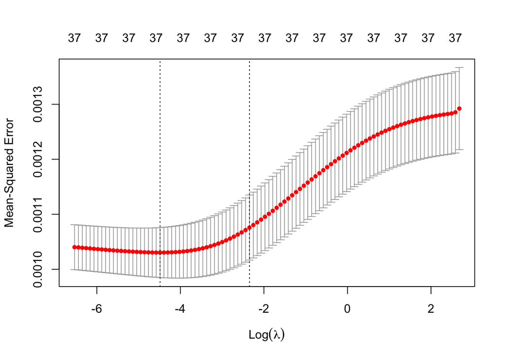

The top 10 coefficients (ranked in order of magnitude) are as follows:

Top 10 Ridge Regression Coefficients with Descriptions

| Feature | Coefficient | Description |
| --- | --- | --- |
| AVG | 0.098 | Batting average – hits per at-bat |
| K.Percent | -0.076 | Strikeout percentage – proportion of plate appearances ending in strikeout |
| BB.Percent | -0.057 | Walk percentage – proportion of plate appearances ending in walk |
| ISO | -0.028 | Isolated power – extra base hits per at-bat |
| BABIP | 0.025 | Batting average on balls in play – luck-independent hitting measure |
| OBP | 0.024 | On-base percentage – times reaching base per plate appearance |
| OPS | 0.006 | On-base plus slugging – overall offensive contribution |
| wOBA | 0.005 | Weighted on-base average – combines OBP and power into single metric |
| SLG | 0.004 | Slugging percentage – total bases per at-bat |
| BB.K | 0.003 | Walk-to-strikeout ratio – plate discipline indicator |

So as we see the most important coefficients are the largest when using regularized regression. It can be reasoned that they contribute more to the reduction of data fit error (Sum of Squared Errors) than they increase the total loss with the penalization of size, indicating that they are important in predicting the response. We examine the effect of the parameters on the predictions again using SHAP in the final comparison section.

## Gradient Boosted Decision Trees Application

```r
# Drop columns and prepare matrices
drop_cols <- c("Season", "Name", "Team", "next_AVG")

x_train_xgb <- as.matrix(train.set[, !(names(train.set) %in% drop_cols)])
y_train_xgb <- train.set$next_AVG

x_val_xgb <- as.matrix(val.set[, !(names(val.set) %in% drop_cols)])
y_val_xgb <- val.set$next_AVG

# Define hyperparameter grids
learning_rates <- c(0.001, 0.01, 0.05, 0.1, 0.2)
subsamples <- c(0.5, 0.7, 1.0)
ntrees <- c(50, 100, 200, 500)

# Store results
xgb_results <- list()

# Function to train and evaluate
train_eval_xgb <- function(eta_val, subsample_val, nrounds_val) {
  dtrain <- xgb.DMatrix(data = x_train_xgb, label = y_train_xgb)
  dval <- xgb.DMatrix(data = x_val_xgb, label = y_val_xgb)

  params <- list(
    objective = "reg:squarederror",  # regression
    eta = eta_val,
    subsample = subsample_val,
    max_depth = 6,                   # fixed for simplicity, can tune later
    eval_metric = "rmse"
  )

  xgb_fit <- xgb.train(
    params = params,
    data = dtrain,
    nrounds = nrounds_val,
    watchlist = list(val = dval),
    verbose = 0
  )

  pred_val <- predict(xgb_fit, dval)
  mse_val <- mean((y_val_xgb - pred_val)^2)

  list(model = xgb_fit, mse = mse_val, eta = eta_val,
       subsample = subsample_val, nrounds = nrounds_val)
}

# Grid search
for (eta_val in learning_rates) {
  for (sub_val in subsamples) {
    for (n_val in ntrees) {
      key <- paste0("xgb_eta_", eta_val, "_sub_", sub_val, "_ntree_", n_val)
      xgb_results[[key]] <- train_eval_xgb(eta_val, sub_val, n_val)
    }
  }
}

# Find best model overall
best_key_xgb <- names(xgb_results)[which.min(sapply(xgb_results, function(x) x$mse))]
best_model_xgb <- xgb_results[[best_key_xgb]]$model
best_mse_xgb <- round(xgb_results[[best_key_xgb]]$mse, 3)
```

Through this analysis, we find that xgb_eta_0.05_sub_0.7_ntree_100 attains the minimum validation RMSE of all XGBoost models tested at (rounded): 0.031623. This indicates that, on average, the model mispredicts the next season’s target by approximately 3.1623%. This is similar to the Regularized Regression model, perhaps indicating that linear relationships between the features and target variable are most prevalent. We proceed to examine the best XGBoost model further using feature importance

### Feature Importance (XGB-Specific)

Top 10 XGBoost Feature Importances with Descriptions

[output not shown]

The columns **`Gain`**, **`Cover`**, and **`Frequency`** in the XGBoost feature importance table have the following meanings (from R help):

- **`Gain`**: Fractional contribution of each feature to the model based on the total gain of this feature’s splits. Higher values indicate more important predictive features.
- **`Cover`**: Relative number of observations affected by splits involving this feature.
- **`Frequency`**: Relative number of times a feature is used in the trees. Higher values mean the feature appears more often across all trees.

Features with Maximal Gain, Cover, and Frequency

| Metric | Feature | Score | Description |
| --- | --- | --- | --- |
| Gain | AVG | 0.115 | Batting average – hits per at-bat |
| Cover | K.Percent | 0.088 | Strikeout percentage – proportion of plate appearances ending in strikeout |
| Frequency | G | 0.112 | Games played – total games in the season |

We again see the last year’s average at the top in terms of gain, indicating that it has the best predictive ability for predicting the next year’s average when considering our models.

### LightGBM

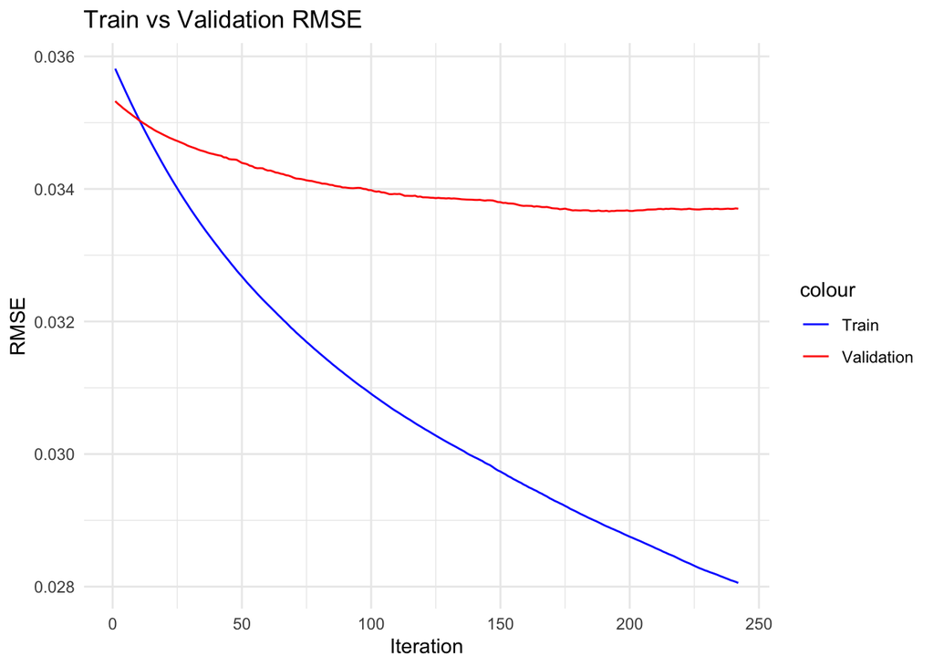

```
## =====================================
##           Best LightGBM Model
## =====================================
## Best Validation RMSE : 0.0337
## Best Training RMSE   : 0.0281
## Best Iteration       : 192
##
## Selected Hyperparameters:
##   learning_rate        : 0.01
##   max_depth            : 6
##   num_leaves           : 8
##   feature_fraction     : 1
##   objective            : regression
##   metric               : rmse
## =====================================
```

### LightGBM Feature Importance

LightGBM - Top 10 Features by Gain

[output not shown]

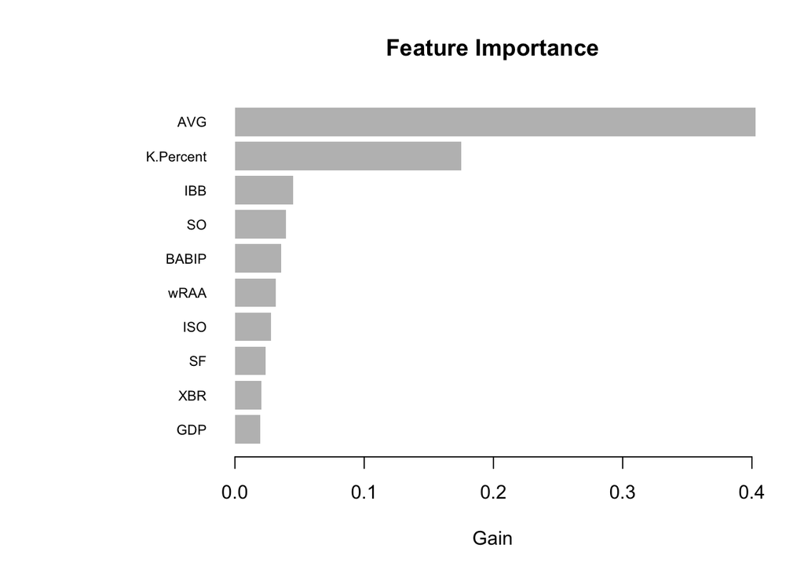

## Comparison of Model Classes

Here we evaluate the best model from each of the previous sections.

### Test Set Evaluation

We evaluate on the test data

```r
library(ggplot2)
library(xgboost)
library(lightgbm)

#Prepare test data same columns as training
drop_cols <- c("Season", "Name", "Team", "next_AVG")
x_test <- as.matrix(test.set[, !(names(test.set) %in% drop_cols)])
y_test <- test.set$next_AVG

#Metrics
rmse <- function(y, yhat) sqrt(mean((y - yhat)^2))
r2   <- function(y, yhat) 1 - sum((y - yhat)^2) / sum((y - mean(y))^2)

#One-to-one plot function
one_to_one_plot <- function(actual, pred, title_text) {
  df <- data.frame(Actual = actual, Predicted = pred)
  ggplot(df, aes(x = Actual, y = Predicted)) +
    geom_point(alpha = 0.5) +
    geom_abline(slope = 1, intercept = 0, linetype = "dashed") +
    labs(
      title = title_text,
      subtitle = paste0("RMSE = ", round(rmse(actual, pred), 5),
                        " | R² = ", round(r2(actual, pred), 5)),
      x = "Actual next_AVG",
      y = "Predicted next_AVG"
    ) +
    theme_minimal()
}

# 1) Regularized Regression (glmnet)
pred_lr <- as.numeric(predict(best_model_lr, s = "lambda.min", newx = x_test))

# 2) XGBoost
pred_xgb <- as.numeric(predict(best_model_xgb, xgb.DMatrix(x_test)))

# 3) LightGBM
pred_lgb <- as.numeric(predict(best_lgb$best_model, x_test,
                               num_iteration = best_lgb$best_model$best_iter))

#Results table
results_test <- data.frame(
  Model = c("Regularized Regression (glmnet)", "XGBoost", "LightGBM"),
  RMSE = c(rmse(y_test, pred_lr), rmse(y_test, pred_xgb), rmse(y_test, pred_lgb)),
  R_Squared = c(r2(y_test, pred_lr), r2(y_test, pred_xgb), r2(y_test, pred_lgb))
)

print(results_test)
```

```
##                             Model       RMSE  R_Squared
## 1 Regularized Regression (glmnet) 0.03020218 0.17673687
## 2                         XGBoost 0.03275313 0.03179384
## 3                        LightGBM 0.03120234 0.12130842
```

```r
knitr::kable(results_test, digits = 5, caption = "Test Set Performance (RMSE and R-Squared)")
```

Test Set Performance (RMSE and R-Squared)

| Model | RMSE | R_Squared |
| --- | --- | --- |
| Regularized Regression (glmnet) | 0.03020 | 0.17674 |
| XGBoost | 0.03275 | 0.03179 |
| LightGBM | 0.03120 | 0.12131 |

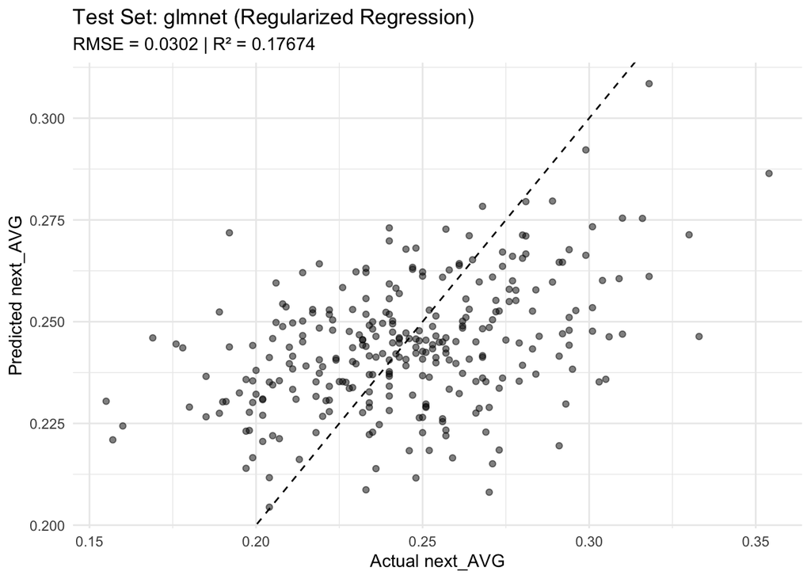

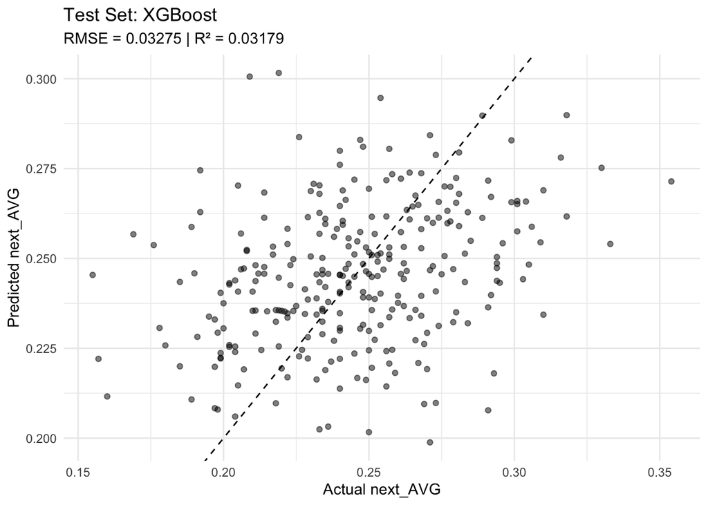

[figure not shown]

```r
#Plots
p_lr  <- one_to_one_plot(y_test, pred_lr,  "Test Set: glmnet (Regularized Regression)")
p_xgb <- one_to_one_plot(y_test, pred_xgb, "Test Set: XGBoost")
p_lgb <- one_to_one_plot(y_test, pred_lgb, "Test Set: LightGBM")

print(p_lr);  print(p_xgb);  print(p_lgb)
```

```r
#Save plots
ggsave("test_one_to_one_glmnet.png",  p_lr,  width = 6, height = 5)
ggsave("test_one_to_one_xgboost.png", p_xgb, width = 6, height = 5)
ggsave("test_one_to_one_lightgbm.png",p_lgb, width = 6, height = 5)
```

### SHAP / IML Analysis (Model-agnostic, TEST set, iml)

We examine model-agnostic explainability results using the *iml* package on the *test set* only.  
This includes global permutation feature importance, partial dependence feature effects, and microscopic Shapley explanations.

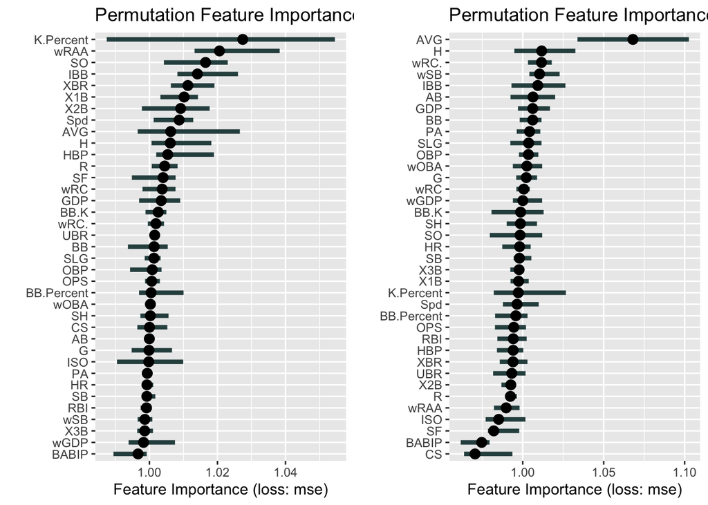

```r
# ---------------------------
# Prepare TEST-set predictor objects (iml)
# ---------------------------
drop_cols <- c("Season", "Name", "Team", "next_AVG")
x_test <- as.matrix(test.set[, !(names(test.set) %in% drop_cols)])
y_test <- test.set$next_AVG
X_test_df <- as.data.frame(x_test)

# predict functions for iml
predict_lr_fun <- function(model, newdata) {
  as.numeric(predict(model, s = "lambda.min", newx = as.matrix(newdata)))
}

predict_xgb_fun <- function(model, newdata) {
  as.numeric(predict(model, xgb.DMatrix(data = as.matrix(newdata))))
}

# iml predictors on TEST set (same X for both models)
predictor_lr_test <- Predictor$new(
  model = best_model_lr,
  data = X_test_df,
  y = y_test,
  predict.fun = predict_lr_fun
)

predictor_xgb_test <- Predictor$new(
  model = best_model_xgb,
  data = X_test_df,
  y = y_test,
  predict.fun = predict_xgb_fun
)

# ---------------------------
# Compute predictions + errors on TEST set
# ---------------------------
pred_test_lr <- predict_lr_fun(best_model_lr, X_test_df)
pred_test_xgb <- predict_xgb_fun(best_model_xgb, X_test_df)

abs_err_lr <- abs(y_test - pred_test_lr)
abs_err_xgb <- abs(y_test - pred_test_xgb)

# ---------------------------
# Global feature importance (Permutation Importance)
# ---------------------------
set.seed(123)
imp_lr_test <- FeatureImp$new(predictor_lr_test, loss = "mse", n.repetitions = 10)
imp_xgb_test <- FeatureImp$new(predictor_xgb_test, loss = "mse", n.repetitions = 10)

p_imp_lr <- plot(imp_lr_test) + ggtitle("Permutation Feature Importance (TEST) - Regularized Regression")
p_imp_xgb <- plot(imp_xgb_test) + ggtitle("Permutation Feature Importance (TEST) - XGBoost")

grid.arrange(p_imp_lr, p_imp_xgb, ncol = 2)
```

```r
# Top-10 importance comparison table
top10_lr <- head(imp_lr_test$results[order(-imp_lr_test$results$importance), c("feature","importance")], 10)
top10_xgb <- head(imp_xgb_test$results[order(-imp_xgb_test$results$importance), c("feature","importance")], 10)

top10_lr$importance <- round(top10_lr$importance, 4)
top10_xgb$importance <- round(top10_xgb$importance, 4)

imp_compare <- data.frame(
  Rank = 1:10,
  LR_Feature = top10_lr$feature,
  LR_Importance = top10_lr$importance,
  XGB_Feature = top10_xgb$feature,
  XGB_Importance = top10_xgb$importance
)

kable(imp_compare, caption = "Top 10 features by permutation importance (TEST set, iml)")
```

Top 10 features by permutation importance (TEST set, iml)

| Rank | LR_Feature | LR_Importance | XGB_Feature | XGB_Importance |
| --- | --- | --- | --- | --- |
| 1 | K.Percent | 1.0274 | AVG | 1.0680 |
| 2 | wRAA | 1.0206 | H | 1.0117 |
| 3 | SO | 1.0165 | wRC. | 1.0116 |
| 4 | IBB | 1.0141 | wSB | 1.0104 |
| 5 | XBR | 1.0113 | IBB | 1.0093 |
| 6 | X1B | 1.0102 | AB | 1.0063 |
| 7 | X2B | 1.0092 | GDP | 1.0062 |
| 8 | Spd | 1.0087 | BB | 1.0062 |
| 9 | AVG | 1.0062 | PA | 1.0043 |
| 10 | H | 1.0061 | SLG | 1.0036 |

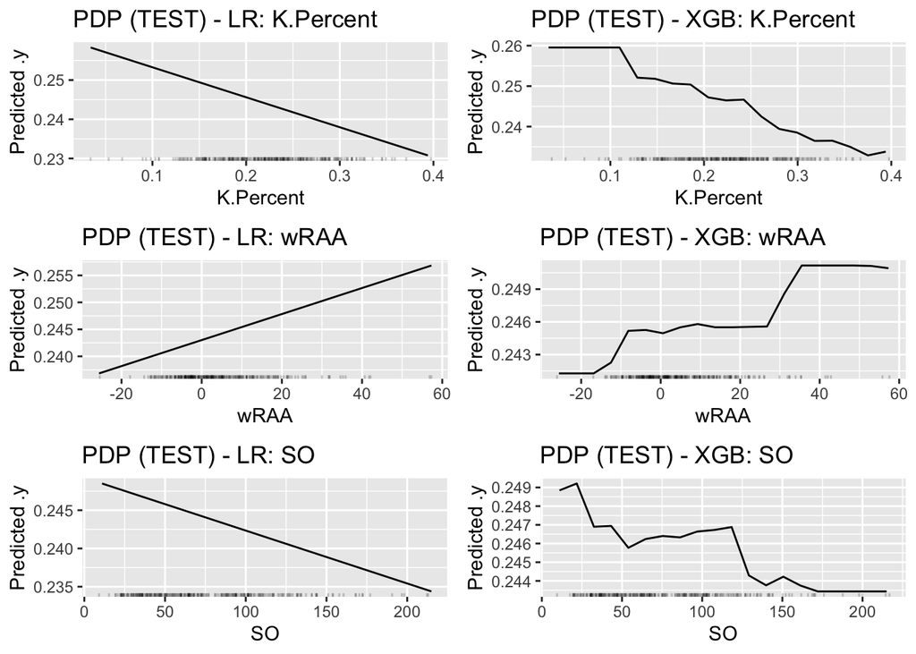

```r
# ---------------------------
# Feature effects (Partial Dependence Plots) for 3 selected features
# ---------------------------
feat_candidates <- unique(c(top10_lr$feature[1:5], top10_xgb$feature[1:5]))
pdp_features <- feat_candidates[1:3]

pdp_plots <- list()
for (i in seq_along(pdp_features)) {
  f <- pdp_features[i]
  fe_lr <- FeatureEffect$new(predictor_lr_test, feature = f, method = "pdp", grid.size = 20)
  fe_xg <- FeatureEffect$new(predictor_xgb_test, feature = f, method = "pdp", grid.size = 20)
  pdp_plots[[2*i - 1]] <- plot(fe_lr) + ggtitle(paste("PDP (TEST) - LR:", f))
  pdp_plots[[2*i]]     <- plot(fe_xg) + ggtitle(paste("PDP (TEST) - XGB:", f))
}
do.call(grid.arrange, c(pdp_plots, ncol = 2))
```

```r
# ---------------------------
# Microscopic explanations (Shapley) for extreme predictions on TEST set
# ---------------------------
rmse_fn <- function(y, yhat) sqrt(mean((y - yhat)^2))
best_model_name <- if (rmse_fn(y_test, pred_test_lr) <= rmse_fn(y_test, pred_test_xgb)) "LR" else "XGB"

idx_high <- which.max(pred_test_xgb)
idx_low  <- which.min(pred_test_xgb)
idx_worst <- if (best_model_name == "LR") which.max(abs_err_lr) else which.max(abs_err_xgb)

case_indices <- unique(c(idx_high, idx_low, idx_worst))
case_indices <- case_indices[1:3]

case_tbl <- data.frame(
  Case = c("Highest predicted (XGB)", "Lowest predicted (XGB)", paste0("Largest error (", best_model_name, ")")),
  Index = case_indices,
  Actual = round(y_test[case_indices], 4),
  Pred_LR = round(pred_test_lr[case_indices], 4),
  Pred_XGB = round(pred_test_xgb[case_indices], 4),
  AbsErr_LR = round(abs_err_lr[case_indices], 4),
  AbsErr_XGB = round(abs_err_xgb[case_indices], 4)
)
kable(case_tbl, caption = "Chosen test-set cases for Shapley explanations")
```

Chosen test-set cases for Shapley explanations

| Case | Index | Actual | Pred_LR | Pred_XGB | AbsErr_LR | AbsErr_XGB |
| --- | --- | --- | --- | --- | --- | --- |
| Highest predicted (XGB) | 138 | 0.219 | 0.2642 | 0.3016 | 0.0452 | 0.0826 |
| Lowest predicted (XGB) | 212 | 0.271 | 0.2151 | 0.1988 | 0.0559 | 0.0722 |
| Largest error (LR) | 225 | 0.333 | 0.2464 | 0.2540 | 0.0866 | 0.0790 |